# Итоговая работа-Copy1

```python
import pandas as pd
import numpy as np
import math as mt
import statistics as stat
import scipy.stats as st
from sklearn import linear_model
import statsmodels.api as sm
import matplotlib.pyplot as plt
import seaborn as sns
```

Набор данных содержит предложения по продаже и аренде квартир из крупнейших городов Польши. Данные взяты с местных сайтов с выставленными на продажу квартирами за март 2024 года.

Рассмотри задачу предсказания **цены квартиры** в зависимости от её конфигурации, а также территориального расположения.

### Подготовка данных

Для начала устраним избыточные столбцы данных, оставив следующие стобцы:

- расстояния до наиболее важных социальных объектов инфраструктуры (школа, детский сад, больница, колледж), а также до центра города;
- площадь квартиры;
- число команат;
- этаж, на котором находится квартира;
- год постройки;
- цена;
- город, в котором она продаётся.

```python
data = pd.read_csv("apartments_rent_pl_2024_03.csv")
data = data[["city", "squareMeters", "rooms", "floor", "buildYear",
             "centreDistance", "schoolDistance", "clinicDistance",
             "kindergartenDistance", "collegeDistance", "price"]]
data = data.dropna()
```

Русифицируем названия городов и столбцов.

```python
data_rus = data.set_axis(['Город', 'Площадь', 'Число комнат', 'Этаж', 'Год постройки',
                          'Расстояние до центра', 'Расстояние до школы', 'Расстояние до больницы',
                          'Расстояние до детского сада', 'Расстояние до универа', 'Цена'], axis=1)

data_rus["Город"].replace('warszawa', "Варшава", inplace=True)
data_rus["Город"].replace('krakow', "Краков", inplace=True)
data_rus["Город"].replace('wroclaw', "Вроцлав", inplace=True)
data_rus["Город"].replace('lodz', "Лодзь", inplace=True)
data_rus["Город"].replace('poznan', "Познань", inplace=True)
data_rus["Город"].replace('gdansk', "Гданьск", inplace=True)
data_rus["Город"].replace('katowice', "Катовице", inplace=True)
data_rus["Город"].replace('szczecin', "Щецин", inplace=True)
data_rus["Город"].replace('gdynia', "Гдыня", inplace=True)
data_rus["Город"].replace('bydgoszcz', "Быдгощ", inplace=True)
data_rus["Город"].replace('lublin', "Люблин", inplace=True)
data_rus["Город"].replace('rzeszow', "Жевуш", inplace=True)
data_rus["Город"].replace('bialystok', "Белосток", inplace=True)
data_rus["Город"].replace('radom', "Радом", inplace=True)
data_rus["Город"].replace('czestochowa', "Честохова", inplace=True)

#в цене при скачивании возникает какая-то опечатка, которая никак не бьётся со здравым смыслом и курсом валют
data_rus["Цена"] = [float(ele)*0.1 for ele in data_rus["Цена"]]

data_rus
```

|  | Город | Площадь | Число комнат | Этаж | Год постройки | Расстояние до центра | Расстояние до школы | Расстояние до больницы | Расстояние до детского сада | Расстояние до универа | Цена |
| --- | --- | --- | --- | --- | --- | --- | --- | --- | --- | --- | --- |
| 0 | Щецин | 35.0 | 2.0 | 4.0 | 2023.0 | 5.07 | 0.165 | 0.987 | 0.561 | 2.282 | 260.0 |
| 1 | Щецин | 80.0 | 3.0 | 2.0 | 2000.0 | 2.45 | 0.385 | 0.237 | 0.051 | 0.488 | 400.0 |
| 3 | Щецин | 28.6 | 1.0 | 10.0 | 1973.0 | 2.57 | 0.220 | 0.791 | 0.290 | 1.832 | 170.0 |
| 4 | Щецин | 35.0 | 1.0 | 1.0 | 2000.0 | 1.12 | 0.576 | 1.037 | 0.356 | 0.616 | 185.0 |
| 5 | Щецин | 43.0 | 2.0 | 3.0 | 1960.0 | 0.30 | 0.072 | 0.730 | 0.114 | 0.405 | 270.0 |
| ... | ... | ... | ... | ... | ... | ... | ... | ... | ... | ... | ... |
| 9139 | Быдгощ | 40.0 | 2.0 | 3.0 | 2023.0 | 2.59 | 0.143 | 0.326 | 0.333 | 1.516 | 240.0 |
| 9142 | Быдгощ | 54.0 | 3.0 | 1.0 | 2022.0 | 0.89 | 0.302 | 1.170 | 0.250 | 0.186 | 360.0 |
| 9143 | Быдгощ | 28.0 | 1.0 | 3.0 | 1980.0 | 4.36 | 0.261 | 0.078 | 0.183 | 1.789 | 130.0 |
| 9148 | Быдгощ | 48.0 | 2.0 | 3.0 | 2019.0 | 0.56 | 0.301 | 0.455 | 0.313 | 0.268 | 270.0 |
| 9149 | Быдгощ | 50.0 | 2.0 | 1.0 | 2019.0 | 0.56 | 0.301 | 0.455 | 0.313 | 0.268 | 280.0 |

5677 rows × 11 columns

### Различие и сходство распределений по факторам в разных группах, а также точечные оценки

Оценим визуально число квартир в 10 наиболее крупных городах.

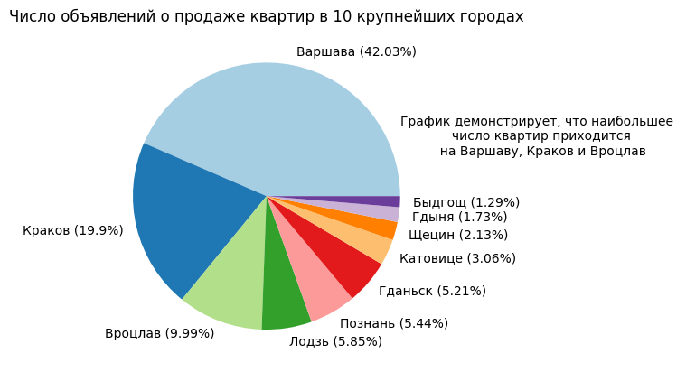

```python
colors = sns.color_palette('Paired')[0:10]
pie_vals_dependents = list(zip(data_rus["Город"].value_counts().index[0:10],
                               round(data_rus["Город"].value_counts(normalize=True) * 100, 2).values))

plt.pie(
    data_rus["Город"].value_counts()[0:10]
    , labels=[i[0] + f" ({i[1]}%)" for i in pie_vals_dependents],
    colors = colors

)

plt.title('Число объявлений о продаже квартир в 10 крупнейших городах')
text_for_boxplot = """
График демонстрирует, что наибольшее
             число квартир приходится
          на Варшаву, Краков и Вроцлав
"""
plt.text(1, 0.2, text_for_boxplot)
plt.show()
```

Посмотрим распределение цен, а также годов постройки домов в трёх наиболее крупных городах.

**Гипотеза 1**: цены в трёх крупных городах будут различаться. В Варшаве будут выше цены, т.к. это столица Польши. В двух других крупнейших городах различие не будет таким значимым.

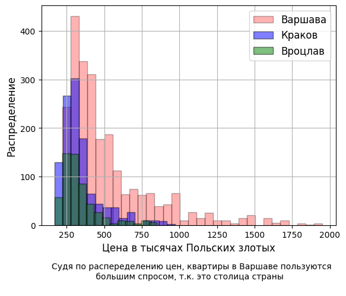

```python
data_var_cen = data_rus[data_rus.Город == "Варшава"]["Цена"]
data_kra_cen = data_rus[data_rus.Город == "Краков"]["Цена"]
data_vro_cen = data_rus[data_rus.Город == "Вроцлав"]["Цена"]


plt.hist(data_var_cen, color = 'r', edgecolor = 'black', label=r'Варшава', alpha = 0.3, bins = 31)
plt.hist(data_kra_cen, color = 'b', edgecolor = 'black', label=r'Краков', alpha = 0.5, bins = 15)
plt.hist(data_vro_cen, color = 'g', edgecolor = 'black', label=r'Вроцлав', alpha = 0.5, bins = 13)
plt.grid(which='major')
plt.legend(fontsize=12)
plt.xlabel(r'Цена в тысячах Польских злотых', fontsize=12)
plt.ylabel(r'Распределение', fontsize=12)
text_for_boxplot = """
Судя по распеределению цен, квартиры в Варшаве пользуются
                 большим спросом, т.к. это столица страны
"""
plt.text(150, -130, text_for_boxplot)
plt.show()
```

Сравним некоторые характеристики распределений.

```python
print("Мода (Варшава):", stat.mode(data_var_cen))
print("Мода (Краков):", stat.mode(data_kra_cen))
print("Мода (Вроцлав):", stat.mode(data_vro_cen), "\n")

print("Среднее значение (Варшава):", stat.mean(data_var_cen))
print("Среднее значение (Краков):", stat.mean(data_kra_cen))
print("Среднее значение (Вроцлав):", stat.mean(data_vro_cen), "\n")

print("Стандартное отклонение (Варшава):", stat.stdev(data_var_cen))
print("Стандартное отклонение (Краков):", stat.stdev(data_kra_cen))
print("Стандартное отклонение (Вроцлав):", stat.stdev(data_vro_cen))
```

```
Мода (Варшава): 350.0
Мода (Краков): 300.0
Мода (Вроцлав): 300.0

Среднее значение (Варшава): 522.0977367979883
Среднее значение (Краков): 339.0084955752212
Среднее значение (Вроцлав): 333.95008818342154

Стандартное отклонение (Варшава): 299.16191961881117
Стандартное отклонение (Краков): 134.3853944493712
Стандартное отклонение (Вроцлав): 125.02597184245847
```

Можно видеть, что среднее значение, мода и стандартное отклонение для распределения цен на квартиры в Варшаве значительно отличаются от других двух крупных городов - Кракова и Вроцлава.

Используем PSI, чтобы оценить различие между распределениями цен.

```python
var = data_var_cen.value_counts(bins=range(150, 850, 75)).sort_index().tolist()
kra = data_kra_cen.value_counts(bins=range(150, 850, 75)).sort_index().tolist()
vro = data_vro_cen.value_counts(bins=range(150, 850, 75)).sort_index().tolist()

var = [ele/len(data_var_cen) for ele in var]
kra = [ele/len(data_kra_cen) for ele in kra]
vro = [ele/len(data_vro_cen) for ele in vro]

PSI_var_kra = st.entropy(var, kra) + st.entropy(kra, var)
PSI_var_vro = st.entropy(var, vro) + st.entropy(vro, var)
PSI_vro_kra = st.entropy(vro, kra) + st.entropy(kra, vro)

print("PSI (Варшава-Краков):", PSI_var_kra)
print("PSI (Варшава-Вроцлав):", PSI_var_vro)
print("PSI (Вроцлав-Краков):", PSI_vro_kra)
```

```
PSI (Варшава-Краков): 0.743632670086553
PSI (Варшава-Вроцлав): 0.6978170305768883
PSI (Вроцлав-Краков): 0.02802557569020469
```

Можно снова констатировать, опираясь на PSI, что распределение цен в Варшаве сильно отличается от Кракова и Вроцлава. Краков и Вроцлав при этом демонстрируют высокую схожесть распределений цен на квартиры.

Посмотрим распределение годов постройки в трёх наиболее крупных городах.

**Гипотеза 2**: Варшава имеет более старый жиличный фонд, т.к. является столицей с 1596 года, а значит этот город наиболее активно застраивался в доиндустриальную эпоху.

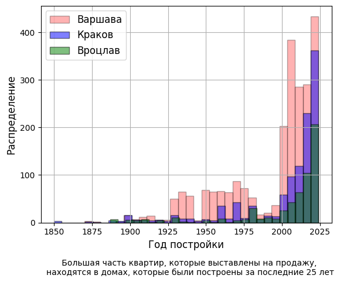

```python
data_var_god = data_rus[data_rus.Город == "Варшава"]["Год постройки"]
data_kra_god = data_rus[data_rus.Город == "Краков"]["Год постройки"]
data_vro_god = data_rus[data_rus.Город == "Вроцлав"]["Год постройки"]

plt.hist(data_var_god, color = 'r', edgecolor = 'black', label=r'Варшава', alpha = 0.3, bins = 30)
plt.hist(data_kra_god, color = 'b', edgecolor = 'black', label=r'Краков', alpha = 0.5, bins = 34)
plt.hist(data_vro_god, color = 'g', edgecolor = 'black', label=r'Вроцлав', alpha = 0.5, bins = 27)
plt.grid(which='major')
plt.legend(fontsize=12)
plt.xlabel(r'Год постройки', fontsize=12)
plt.ylabel(r'Распределение', fontsize=12)
text_for_boxplot = """
      Большая часть квартир, которые выставлены на продажу,
находятся в домах, которые были построены за последние 25 лет
"""
plt.text(1845, -130, text_for_boxplot)
plt.show()
```

Сравним некоторые характеристики распределений.

```python
print("Мода (Варшава):", stat.mode(data_var_god))
print("Мода (Краков):", stat.mode(data_kra_god))
print("Мода (Вроцлав):", stat.mode(data_vro_god), "\n")

print("Среднее значение (Варшава):", stat.mean(data_var_god))
print("Среднее значение (Краков):", stat.mean(data_kra_god))
print("Среднее значение (Вроцлав):", stat.mean(data_vro_god), "\n")

print("Стандартное отклонение (Варшава):", stat.stdev(data_var_god))
print("Стандартное отклонение (Краков):", stat.stdev(data_kra_god))
print("Стандартное отклонение (Вроцлав):", stat.stdev(data_vro_god))
```

```
Мода (Варшава): 2023.0
Мода (Краков): 2022.0
Мода (Вроцлав): 2022.0

Среднее значение (Варшава): 1993.6051969823973
Среднее значение (Краков): 2000.9088495575222
Среднее значение (Вроцлав): 2002.6596119929454

Стандартное отклонение (Варшава): 30.457394344472128
Стандартное отклонение (Краков): 31.25097144997655
Стандартное отклонение (Вроцлав): 30.31132061534696
```

Значительно распределения годов постройки домов отличаются только средними значениями. У Варшавы этот показатель ниже.

Используем PSI, чтобы оценить различие между распределениями годов постройки домов.

```python
var = data_var_god.value_counts(bins=range(1884, 2024, 10)).sort_index().tolist()
kra = data_kra_god.value_counts(bins=range(1884, 2024, 10)).sort_index().tolist()
vro = data_vro_god.value_counts(bins=range(1884, 2024, 10)).sort_index().tolist()

var = [ele/len(data_var_god) for ele in var]
kra = [ele/len(data_kra_god) for ele in kra]
vro = [ele/len(data_vro_god) for ele in vro]

PSI_var_kra = st.entropy(var, kra) + st.entropy(kra, var)
PSI_var_vro = st.entropy(var, vro) + st.entropy(vro, var)
PSI_vro_kra = st.entropy(vro, kra) + st.entropy(kra, vro)

print("PSI (Варшава-Краков):", PSI_var_kra)
print("PSI (Варшава-Вроцлав):", PSI_var_vro)
print("PSI (Вроцлав-Краков):", PSI_vro_kra)
```

```
PSI (Варшава-Краков): 0.1567566883689081
PSI (Варшава-Вроцлав): 0.5395427468179237
PSI (Вроцлав-Краков): 0.20471847965194237
```

Можно констатировать, опираясь на PSI, что распределение годов постройки домов, в которых продаются квартиры, сильно отличается между собой во всех трёх городах. Наибольшее различие наблюдается между Варшавой и Вроцлавом.

### Построение интервальных оценок

Построение эфроновых доверительных интервалов.

```python
#формируем выборки
var_cen_bt = []
kra_cen_bt = []
vro_cen_bt = []
var_god_bt = []
kra_god_bt = []
vro_god_bt = []

#размер выборок
N = 5000

for i in range(N):
    var_cen_bt.append(np.random.choice(data_var_cen, 500, replace = True).mean())
    kra_cen_bt.append(np.random.choice(data_kra_cen, 500, replace = True).mean())
    vro_cen_bt.append(np.random.choice(data_vro_cen, 500, replace = True).mean())
    var_god_bt.append(np.random.choice(data_var_god, 500, replace = True).mean())
    kra_god_bt.append(np.random.choice(data_kra_god, 500, replace = True).mean())
    vro_god_bt.append(np.random.choice(data_vro_god, 500, replace = True).mean())
```

```python
#средние значения
m_vc, m_krc, m_vrc = np.mean(var_cen_bt), np.mean(kra_cen_bt), np.mean(vro_cen_bt)
m_vg, m_krg, m_vrg = np.mean(var_god_bt), np.mean(kra_god_bt), np.mean(vro_god_bt)

#дисперсии
var_vc, var_krc, var_vrc = np.var(var_cen_bt), np.var(kra_cen_bt), np.var(vro_cen_bt)
var_vg, var_krg, var_vrg = np.var(var_god_bt), np.var(kra_god_bt), np.var(vro_god_bt)

#разницы матожиданий
dm_vc_krc = m_vc-m_krc
dm_vc_vrc = m_vc-m_vrc
dm_krc_vrc = m_krc-m_vrc
dm_vg_krg = m_vg-m_krg
dm_vg_vrg = m_vg-m_vrg
dm_krg_vrg = m_krg-m_vrg

#разницы дисперсий
dvar_vc_krc = (var_vc+var_krc)/N
dvar_vc_vrc = (var_vc+var_vrc)/N
dvar_krc_vrc = (var_krc+var_vrc)/N
dvar_vg_krg = (var_vg+var_krg)/N
dvar_vg_vrg = (var_vg+var_vrg)/N
dvar_krg_vrg = (var_vrg+var_krg)/N

alpha = 0.05

#расчёт критических значений
t = st.t(2*N-2)

t_crit = t.ppf(1-alpha/2)

#расчёт границ интервалов
left_N_vc_krc = dm_vc_krc - t_crit*mt.sqrt(dvar_vc_krc)
left_N_vc_vrc = dm_vc_vrc - t_crit*mt.sqrt(dvar_vc_vrc)
left_N_krc_vrc = dm_krc_vrc - t_crit*mt.sqrt(dvar_krc_vrc)
left_N_vg_krg = dm_vg_krg - t_crit*mt.sqrt(dvar_vg_krg)
left_N_vg_vrg = dm_vg_vrg - t_crit*mt.sqrt(dvar_vg_vrg)
left_N_krg_vrg = dm_krg_vrg - t_crit*mt.sqrt(dvar_krg_vrg)

right_N_vc_krc = dm_vc_krc + t_crit*mt.sqrt(dvar_vc_krc)
right_N_vc_vrc = dm_vc_vrc + t_crit*mt.sqrt(dvar_vc_vrc)
right_N_krc_vrc = dm_krc_vrc + t_crit*mt.sqrt(dvar_krc_vrc)
right_N_vg_krg = dm_vg_krg + t_crit*mt.sqrt(dvar_vg_krg)
right_N_vg_vrg = dm_vg_vrg + t_crit*mt.sqrt(dvar_vg_vrg)
right_N_krg_vrg = dm_krg_vrg + t_crit*mt.sqrt(dvar_krg_vrg)
```

```python
print('Интервал для различия средней цены за квартиру в Варшаве и Кракове:', '\n', (left_N_vc_krc, right_N_vc_krc))
print('Интервал для различия средней цены за квартиру в Варшаве и Вроцлаве:', '\n', (left_N_vc_vrc, right_N_vc_vrc))
print('Интервал для различия средней цены за квартиру в Вроцлаве и Кракове:', '\n', (left_N_krc_vrc, right_N_krc_vrc))
```

```
Интервал для различия средней цены за квартиру в Варшаве и Кракове:
 (182.20043989674477, 183.01348914325516)
Интервал для различия средней цены за квартиру в Варшаве и Вроцлаве:
 (187.27501417511255, 188.08093558488738)
Интервал для различия средней цены за квартиру в Вроцлаве и Кракове:
 (4.843541564283809, 5.298479155716196)
```

```python
print('Интервал для различия среднего значения года постройки квартиры в Варшаве и Кракове:', '\n', (left_N_vg_krg, right_N_vg_krg))
print('Интервал для различия среднего значения года постройки квартиры в Варшаве и Вроцлаве:', '\n', (left_N_vg_vrg, right_N_vg_vrg))
print('Интервал для различия среднего значения года постройки квартиры в Вроцлаве и Кракове:', '\n', (left_N_krg_vrg, right_N_krg_vrg))
```

```
Интервал для различия среднего значения года постройки квартиры в Варшаве и Кракове:
 (-7.35096979887538, -7.243296601124089)
Интервал для различия среднего значения года постройки квартиры в Варшаве и Вроцлаве:
 (-9.120737531994497, -9.01456406800487)
Интервал для различия среднего значения года постройки квартиры в Вроцлаве и Кракове:
 (-1.823955739785166, -1.7170794602147306)
```

**Гипотеза 1**: подтверждена.

Чтобы частично сравнять средние цены в городах, можно отбросить данные о премиум жилье в столице, установив для неё верхнюю планку по цене на квартиры.

**Гипотеза 2**: опровергнута. Во время Второй Мировой войны Варшава была уничтожена примерно на 85% в отличие от двух других рассматриваемых городов. Поэтому сразу после войны шло её активное восстановление и застройка. Также видно, что после мирового кризиса 2008 года относительные (относительно всего построенных домов в каждом городе) темпы строительства в городах стали сравниваться, а ближе к настоящему времени Краков и Вроцлав даже стали опережать Варшаву по относительным темпам строительства.

Чтобы выравнять год постройки домов, можно установить для него ограничение снизу. Если бы городом являлся Санкт-Петербург (имеет обширный исторический центр), то путём установления границы снизу на расстояние от центра города, можно было бы увеличить среднее значение года постройки домов рассматриваемых квартир.

В случае Варшавы затруднюясь точно ответить, сработал бы данный способ или нет, но, скорее всего, да, т.к. там тоже должен быть исторический центр, а спальные районы должны располагатьсь ближе к окраинам.

### Построение базовой модели линейной регрессии методом МНК

```python
Cost = data_rus['Цена'].tolist()
Square = data_rus['Площадь'].tolist()
Number_of_rooms = data_rus['Число комнат'].tolist()
Floor = data_rus['Этаж'].tolist()
Year = data_rus['Год постройки'].tolist()
Dist_cent = data_rus['Расстояние до центра'].tolist()
Dist_school = data_rus['Расстояние до школы'].tolist()
Dist_hosp = data_rus['Расстояние до больницы'].tolist()
Dist_kindergar = data_rus['Расстояние до детского сада'].tolist()
Dist_univer = data_rus['Расстояние до универа'].tolist()

col_names = ["Square", "Number_of_rooms", "Floor", "Year", "Dist_cent",
             "Dist_school", "Dist_hosp", "Dist_kindergar", "Dist_univer"]
col_names_rus = ['Площадь', 'Число комнат', 'Этаж', 'Год постройки',
                'Расстояние до центра', 'Расстояние до школы', 'Расстояние до больницы',
                'Расстояние до детского сада', 'Расстояние до универа']
```

Подписи к графикам, названия осей, выводы по графикам и полученным коэффициентам

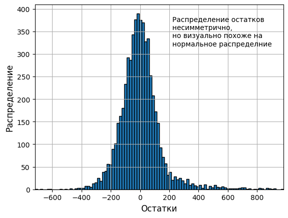

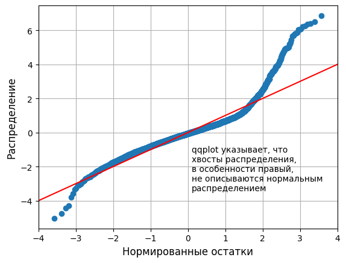

```
Значение pvalue нормальности распределения остатков: 0.0
Среднее значение отклонения реального и смоделированного значений цены: 142.7347029736978
```

```python
model = linear_model.LinearRegression().fit(np.concatenate([[Square],[Number_of_rooms],[Floor],
                                                           [Year],[Dist_cent],[Dist_school],
                                                           [Dist_hosp],[Dist_kindergar],[Dist_univer]]).T, Cost)
intercept = model.intercept_
beta = model.coef_

Cost_teor = intercept

for i in range(9):
    Cost_teor += beta[i]*data_rus[col_names_rus[i]]

delta = Cost-Cost_teor

plt.hist(delta, edgecolor = 'black', bins = 100)
plt.grid(which='major')
plt.xlabel(r'Остатки', fontsize=12)
plt.ylabel(r'Распределение', fontsize=12)
plt.xlim([min(delta), max(delta)])
text_for_boxplot = """
Распределение остатков
несимметрично,
но визуально похоже на
нормальное распределние
"""
plt.text(220, 300, text_for_boxplot)

fig = sm.qqplot((delta-stat.mean(delta))/stat.stdev(delta), line='45')
plt.grid(which='major')
plt.xlabel(r'Нормированные остатки', fontsize=12)
plt.ylabel(r'Распределение', fontsize=12)
plt.xlim([-4, 4])
text_for_boxplot = """
qqplot указывает, что
хвосты распределения,
в особенности правый,
не описываются нормальным
распределением
"""
plt.text(0.1, -4, text_for_boxplot)
plt.show()

print('Значение pvalue нормальности распределения остатков:',st.normaltest((delta-stat.mean(delta))/stat.stdev(delta)).pvalue)
print('Среднее значение отклонения реального и смоделированного значений цены:',mt.sqrt(stat.mean([ele**2 for ele in delta])))
```

Исходя из qqplot и теста на нормальность, можно констатировать, что распределение остатков не описывается нормальным распределением.

```python
print('Beta0:', intercept)
for i in range(9):
    print(f'Beta{i+1}({col_names[i]}):', beta[i])
```

```
Beta0: -1154.6746387041546
Beta1(Square): 8.785716349003975
Beta2(Number_of_rooms): -14.733413997548935
Beta3(Floor): 5.113496629459939
Beta4(Year): 0.5646185301186328
Beta5(Dist_cent): -1.5439622234205816
Beta6(Dist_school): 0.3383972914621899
Beta7(Dist_hosp): -20.96288161757182
Beta8(Dist_kindergar): -18.987632489986964
Beta9(Dist_univer): -15.723590358729764
```

Некоторые коэффициенты Beta также вызывают подозрение. Beta2 (число комнат) и Beta6 (расстояние до школы), исходя из логики, должны иметь противоположные знаки.

Скорее всего, некоторые из предпосылок МНК нарушаются. Проведём тест на мультиколлинеарность.

### Тест на мультиколлинеарность

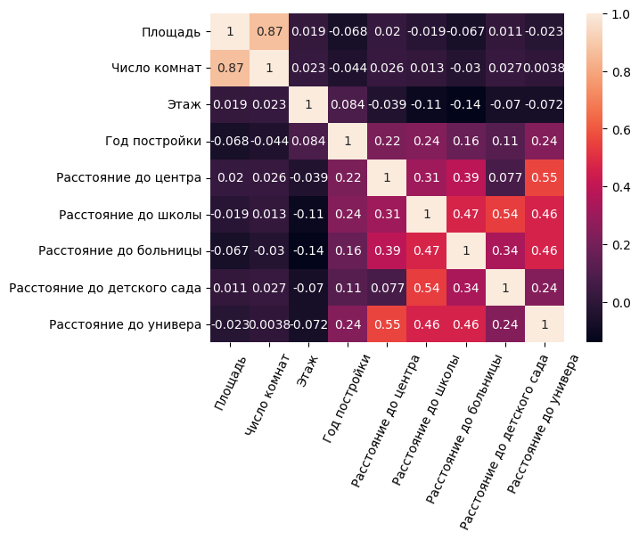

```python
hm = sns.heatmap(data_rus.iloc[:,range(1,10)].corr(), annot=True)
plt.xticks(rotation=65)
plt.show()
```

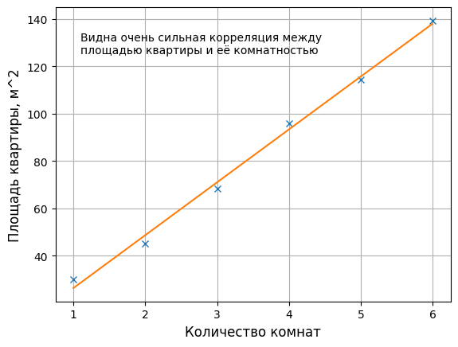

```python
square_mean = []
floors = [[ele] for ele in range(1,7)]
for i in range(6):
    square_mean.append(stat.mean(data_rus[data_rus['Число комнат'] == (i+1)]['Площадь']))

model_fl_sq = linear_model.LinearRegression().fit(np.array(floors), np.array(square_mean))
intercept_fl_sq = model_fl_sq.intercept_
beta_fl_sq = model_fl_sq.coef_

square_mean_teor = intercept_fl_sq + beta_fl_sq[0]*np.array(floors)

plt.plot(floors,square_mean,'x')
plt.plot(floors,square_mean_teor)
plt.grid(which='major')
plt.xlabel(r'Количество комнат', fontsize=12)
plt.ylabel(r'Площадь квартиры, м^2', fontsize=12)
text_for_boxplot = """
Видна очень сильная корреляция между
площадью квартиры и её комнатностью
"""
plt.text(1.1, 120, text_for_boxplot)
plt.show()
```

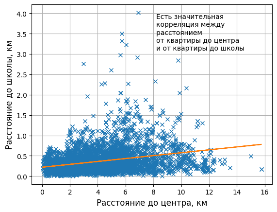

```python
Dist_cent_ar = [[ele] for ele in Dist_cent]
model_dc_ds = linear_model.LinearRegression().fit(np.array(Dist_cent_ar), np.array(Dist_school))
intercept_dc_ds = model_dc_ds.intercept_
beta_dc_ds = model_dc_ds.coef_

Dist_school_teor = intercept_dc_ds + beta_dc_ds[0]*np.array(Dist_cent_ar)

plt.plot(Dist_cent,Dist_school,'x')
plt.plot(Dist_cent,Dist_school_teor)
plt.grid(which='major')
plt.xlabel(r'Расстояние до центра, км', fontsize=12)
plt.ylabel(r'Расстояние до школы, км', fontsize=12)
text_for_boxplot = """
Есть значительная
корреляция между
расстоянием
от квартиры до центра
и от квартиры до школы
"""
plt.text(8.2, 2.9, text_for_boxplot)
plt.show()
```

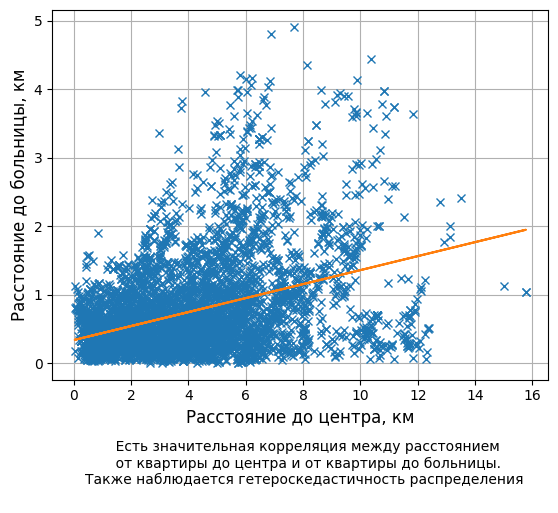

```python
model_dc_dh = linear_model.LinearRegression().fit(np.array(Dist_cent_ar), np.array(Dist_hosp))
intercept_dc_dh = model_dc_dh.intercept_
beta_dc_dh = model_dc_dh.coef_

Dist_hosp_teor = intercept_dc_dh + beta_dc_dh[0]*np.array(Dist_cent_ar)

plt.plot(Dist_cent,Dist_hosp,'x')
plt.plot(Dist_cent,Dist_hosp_teor)
plt.grid(which='major')
plt.xlabel(r'Расстояние до центра, км', fontsize=12)
plt.ylabel(r'Расстояние до больницы, км', fontsize=12)
text_for_boxplot = """
       Есть значительная корреляция между расстоянием
       от квартиры до центра и от квартиры до больницы.
Также наблюдается гетероскедастичность распределения
"""
plt.text(0.4, -2, text_for_boxplot)
plt.show()
```

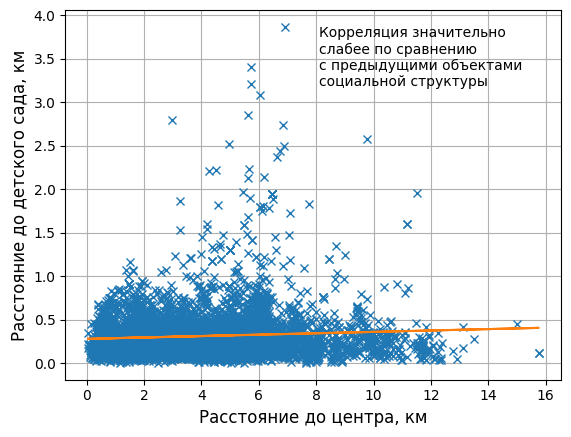

```python
model_dc_dk = linear_model.LinearRegression().fit(np.array(Dist_cent_ar), np.array(Dist_kindergar))
intercept_dc_dk = model_dc_dk.intercept_
beta_dc_dk = model_dc_dk.coef_

Dist_kindergar_teor = intercept_dc_dk + beta_dc_dk[0]*np.array(Dist_cent_ar)

plt.plot(Dist_cent,Dist_kindergar,'x')
plt.plot(Dist_cent,Dist_kindergar_teor)
plt.grid(which='major')
plt.xlabel(r'Расстояние до центра, км', fontsize=12)
plt.ylabel(r'Расстояние до детского сада, км', fontsize=12)
text_for_boxplot = """
Корреляция значительно
слабее по сравнению
с предыдущими объектами
социальной структуры
"""
plt.text(8.1, 3, text_for_boxplot)
plt.show()
```

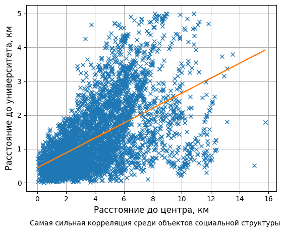

```python
model_dc_du = linear_model.LinearRegression().fit(np.array(Dist_cent_ar), np.array(Dist_univer))
intercept_dc_du = model_dc_du.intercept_
beta_dc_du = model_dc_du.coef_

Dist_univer_teor = intercept_dc_du + beta_dc_du[0]*np.array(Dist_cent_ar)

plt.plot(Dist_cent,Dist_univer,'x')
plt.plot(Dist_cent,Dist_univer_teor)
plt.grid(which='major')
plt.xlabel(r'Расстояние до центра, км', fontsize=12)
plt.ylabel(r'Расстояние до университета, км', fontsize=12)
text_for_boxplot = """
Самая сильная корреляция среди объектов социальной структуры
"""
plt.text(-0.5, -1.5, text_for_boxplot)
plt.show()
```

В дальнейшем будем рассматривать только слабокоррелирующие признаки - площадь, этаж, год постройки дома, расстояние до центра.

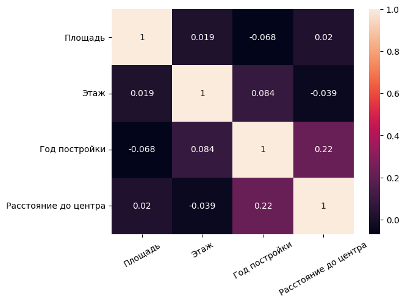

```python
hm = sns.heatmap(data_rus.iloc[:,[1,3,4,5]].corr(), annot=True)
plt.xticks(rotation=30)
plt.show()
```

### Построение второй модели, проверка её на гетероскедастичность

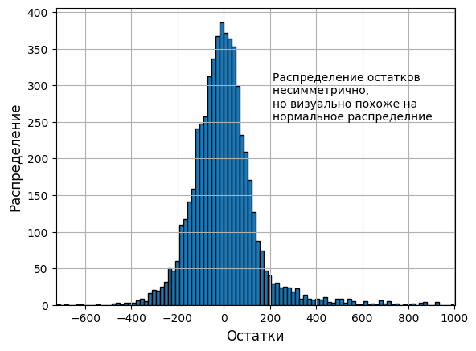

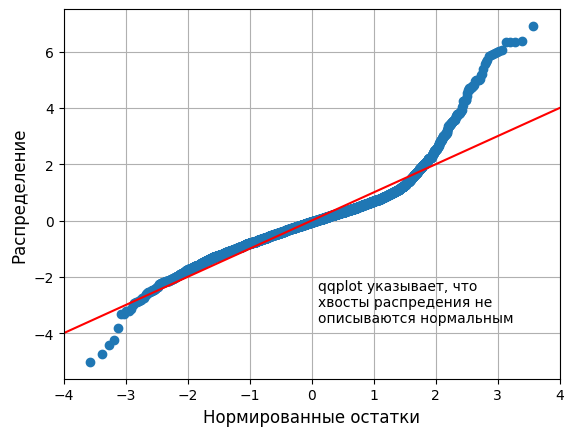

```
Значение pvalue нормальности распределения остатков: 0.0
Среднее значение отклонения реального и смоделированного значений цены: 144.74068420302612
```

```python
col_names_2 = ["Square", "Floor", "Year", "Dist_cent"]
col_names_rus_2 = ['Площадь', 'Этаж', 'Год постройки', 'Расстояние до центра']

model_2 = linear_model.LinearRegression().fit(np.concatenate([[Square],[Floor],[Year],[Dist_cent]]).T, Cost)
intercept_2 = model_2.intercept_
beta_2 = model_2.coef_

Cost_teor_2 = intercept_2

for i in range(4):
    Cost_teor_2 += beta_2[i]*data_rus[col_names_rus_2[i]]

delta_2 = Cost-Cost_teor_2

plt.hist(delta_2, edgecolor = 'black', bins = 100)
plt.grid(which='major')
plt.xlabel(r'Остатки', fontsize=12)
plt.ylabel(r'Распределение', fontsize=12)
plt.xlim([min(delta_2), max(delta_2)])
text_for_boxplot = """
Распределение остатков
несимметрично,
но визуально похоже на
нормальное распределние
"""
plt.text(210, 235, text_for_boxplot)

fig = sm.qqplot((delta_2-stat.mean(delta_2))/stat.stdev(delta_2), line='45')
plt.grid(which='major')
plt.xlabel(r'Нормированные остатки', fontsize=12)
plt.ylabel(r'Распределение', fontsize=12)
plt.xlim([-4, 4])
text_for_boxplot = """
qqplot указывает, что
хвосты распредения не
описываются нормальным
"""
plt.text(0.1, -4.2, text_for_boxplot)
plt.show()

print('Значение pvalue нормальности распределения остатков:',st.normaltest((delta_2-stat.mean(delta_2))/stat.stdev(delta_2)).pvalue)
print('Среднее значение отклонения реального и смоделированного значений цены:',mt.sqrt(stat.mean([ele**2 for ele in delta_2])))
```

```python
np.array(data_rus[col_names_rus_2[1]])
```

```
array([ 4.,  2., 10., ...,  3.,  3.,  1.])
```

Исходя из qqplot и теста на нормальность, можно констатировать, что распределение остатков не описывается нормальным распределением.

```python
print('Beta0:', intercept_2)
for i in range(4):
    print(f'Beta{i+1}({col_names_2[i]}):', beta_2[i])
```

```
Beta0: -926.9391347146147
Beta1(Square): 8.341070899952781
Beta2(Floor): 6.296967491506243
Beta3(Year): 0.43302188697381805
Beta4(Dist_cent): -6.959892775371308
```

Коэффициенты Beta имеют реалистичные значения, однако среденее значение отклонения теоретической цены от реальной, практически не изменилось. Необходимо проверить оставшиеся признаки, прошедшие тест на мультиколлинеарность, на гетероскедастичность.

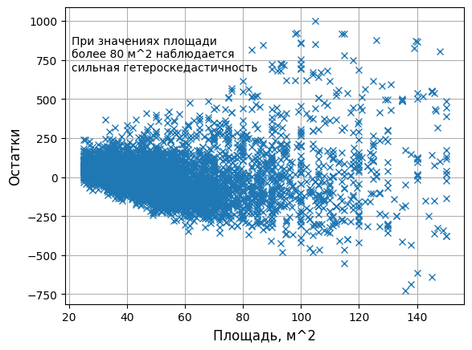

```python
plt.plot(Square,delta_2,'x')
plt.grid(which='major')
plt.xlabel(r'Площадь, м^2', fontsize=12)
plt.ylabel(r'Остатки', fontsize=12)
text_for_boxplot = """
При значениях площади
более 80 м^2 наблюдается
сильная гетероскедастичность
"""
plt.text(21, 600, text_for_boxplot)
plt.show()
```

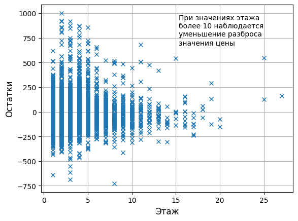

```python
plt.plot(Floor,delta_2,'x')
plt.grid(which='major')
plt.xlabel(r'Этаж', fontsize=12)
plt.ylabel(r'Остатки', fontsize=12)
text_for_boxplot = """
При значениях этажа
более 10 наблюдается
уменьшение разброса
значения цены
"""
plt.text(15.3, 600, text_for_boxplot)
plt.show()
```

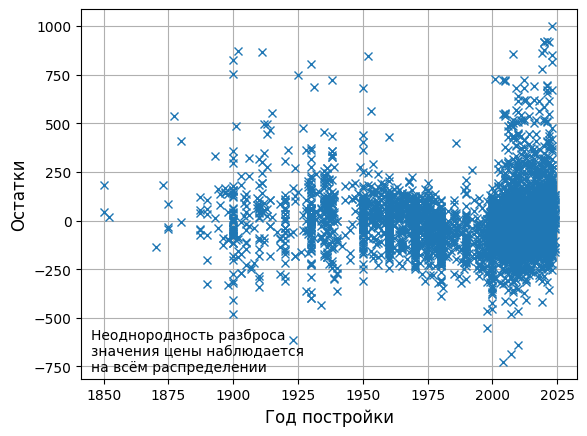

```python
plt.plot(Year,delta_2,'x')
plt.grid(which='major')
plt.xlabel(r'Год постройки', fontsize=12)
plt.ylabel(r'Остатки', fontsize=12)
text_for_boxplot = """
Неоднородность разброса
значения цены наблюдается
на всём распределении
"""
plt.text(1845, -860, text_for_boxplot)
plt.show()
```

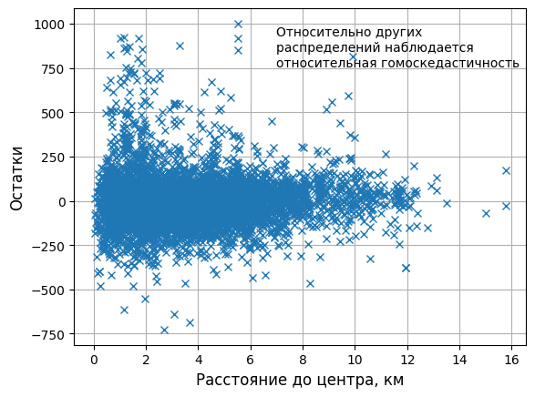

```python
plt.plot(Dist_cent,delta_2,'x')
plt.grid(which='major')
plt.xlabel(r'Расстояние до центра, км', fontsize=12)
plt.ylabel(r'Остатки', fontsize=12)
text_for_boxplot = """
Относительно других
распределений наблюдается
относительная гомоскедастичность
"""
plt.text(7, 680, text_for_boxplot)
plt.show()
```

```python
print('Значение pvalue теста Голдфелда — Куандта:',sm.stats.diagnostic.het_goldfeldquandt(delta_2, data_rus[col_names_rus_2], drop = 0.2)[1])
```

```
Значение pvalue теста Голдфелда — Куандта: 1.806659683999366e-207
```

Тест Голдфелда — Куандта на гетероскедастичность показывает крайне низкий результат

### Первая модифицикация второй модели модели

Попытаемся предпринять следующие шаги:

- Зависимость цены от площади имеет немного экспоненциальную зависимость, поэтому будем искать линейную зависимость не от площади, а от exp(площадь)
- Уберём год постройки, т.к. как упоминалось ранее, он имеет корреляцию с расстоянием до центра
- Уберём этаж, т.к. исходя из здравого смысла данная величина не должна сильно влиять на конечную цену, если это не первый и не последний этаж. Исключение возможно, если речь идет о застройке новыми домами, которые могут иметь большую цену и большую высотность. Т.е. большие значения этажей могут коррелировать с ценой на квартиру (в старых домах нет высоких этажей в отличие от новых и потенциально с более дорогими квартирами). Также величина этажей - это дискретная величина. Также этаж не является в полном смысле непрерывной величиной, т.к. принимает только целочисленные значения
- После расчётов искуственно сдвинем интерцепт на константу, чтобы распределение остатков было симметрично относительно нуля

Была также попытка попробовать ввести веса для разных значений этажа, но она не увенчалось положительным результатом, поэтому, чтобы не загрязнять код, она здесь не приводится.

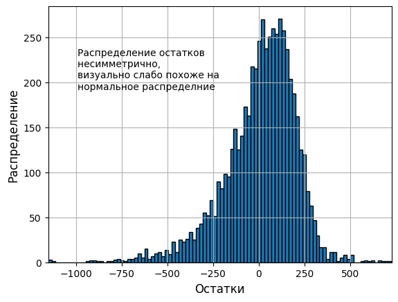

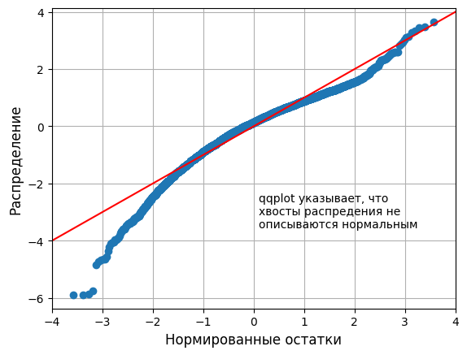

```
Значение pvalue нормальности распределения остатков: 1.7795876585115876e-208
Среднее значение отклонения реального и смоделированного значений цены: 196.88601074040974
Значение pvalue теста Голдфелда — Куандта: 1.9641527821846197e-53
```

```python
Sq = (23*np.exp(0.011*data_rus['Площадь'])).tolist()
model_2_mod = linear_model.LinearRegression().fit(np.concatenate([[Sq],[Dist_cent]]).T, Cost)
intercept_2_mod = model_2_mod.intercept_
beta_2_mod = model_2_mod.coef_

sdvig = -170
Cost_teor_2_mod = (intercept_2_mod+sdvig) + beta_2_mod[0]*data_rus['Площадь'] + beta_2_mod[1]*data_rus['Расстояние до центра']

delta_2_mod = Cost-Cost_teor_2_mod

plt.hist(delta_2_mod, edgecolor = 'black', bins = 100)
plt.grid(which='major')
plt.xlabel(r'Остатки', fontsize=12)
plt.ylabel(r'Распределение', fontsize=12)
plt.xlim([min(delta_2_mod), max(delta_2_mod)])
text_for_boxplot = """
Распределение остатков
несимметрично,
визуально слабо похоже на
нормальное распределние
"""
plt.text(-990, 180, text_for_boxplot)

fig = sm.qqplot((delta_2_mod-stat.mean(delta_2_mod))/stat.stdev(delta_2_mod), line='45')
plt.grid(which='major')
plt.xlabel(r'Нормированные остатки', fontsize=12)
plt.ylabel(r'Распределение', fontsize=12)
plt.xlim([-4, 4])
text_for_boxplot = """
qqplot указывает, что
хвосты распредения не
описываются нормальным
"""
plt.text(0.1, -4, text_for_boxplot)
plt.show()

print('Значение pvalue нормальности распределения остатков:',st.normaltest((delta_2_mod-stat.mean(delta_2_mod))/stat.stdev(delta_2_mod)).pvalue)
print('Среднее значение отклонения реального и смоделированного значений цены:',mt.sqrt(stat.mean([ele**2 for ele in delta_2_mod])))
print('Значение pvalue теста Голдфелда — Куандта:',sm.stats.diagnostic.het_goldfeldquandt(delta_2_mod, data_rus[["Площадь", "Расстояние до центра"]], drop = 0.2)[1])
```

По итогу модификаций результаты оказались хуже, чем были в модели после проверки на мультиколлинеарность. Среднее значение отклонений увеличилось, однако гетероскедастичность удалось понизить.

### Вторая модификация второй модели

Попробуем построить модель для конкретного города - Варшавы, чтобы нивелировать негативные эффекты, связанные с разными распределениями цен на квартиры в городах.

Также установим конкретный ценовой диапазон.

```python
data_rus_mod = data_rus[data_rus['Город'] == 'Варшава'][data_rus['Цена'] <= 1000][data_rus['Цена'] >= 400]
Cost_mod = data_rus_mod['Цена'].tolist()
Dist_cent_mod = data_rus_mod['Расстояние до центра'].tolist()
Sq = (23*np.exp(0.011*data_rus_mod['Площадь'])).tolist()
```

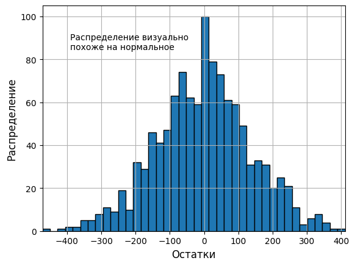

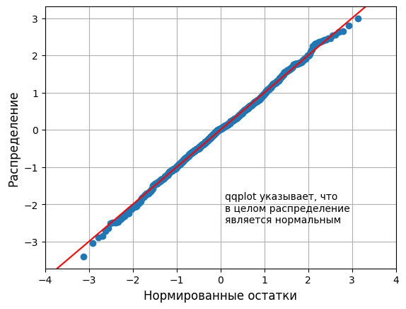

```
Значение pvalue нормальности распределения остатков: 0.6854099261495179
Среднее значение отклонения реального и смоделированного значений цены: 138.02225714313096
Значение pvalue теста Голдфелда — Куандта: 8.640910309517883e-05
```

```python
model_2_mod_2 = linear_model.LinearRegression().fit(np.concatenate([[Sq],[Dist_cent_mod]]).T, Cost_mod)
intercept_2_mod_2 = model_2_mod_2.intercept_
beta_2_mod_2 = model_2_mod_2.coef_

sdvig = -155
Cost_teor_2_mod_2 = (intercept_2_mod_2+sdvig)  + beta_2_mod_2[0]*data_rus_mod['Площадь'] + beta_2_mod_2[1]*data_rus_mod['Расстояние до центра']


beta_2_mod

delta_2_mod_2 = Cost_mod-Cost_teor_2_mod_2

plt.hist(delta_2_mod_2, edgecolor = 'black', bins = 40)
plt.grid(which='major')
plt.xlabel(r'Остатки', fontsize=12)
plt.ylabel(r'Распределение', fontsize=12)
plt.xlim([min(delta_2_mod_2), max(delta_2_mod_2)])
text_for_boxplot = """
Распределение визуально
похоже на нормальное
"""
plt.text(-390, 80, text_for_boxplot)

fig = sm.qqplot((delta_2_mod_2-stat.mean(delta_2_mod_2))/stat.stdev(delta_2_mod_2), line='45')
plt.grid(which='major')
plt.xlabel(r'Нормированные остатки', fontsize=12)
plt.ylabel(r'Распределение', fontsize=12)
plt.xlim([-4, 4])
text_for_boxplot = """
qqplot указывает, что
в целом распределение
является нормальным
"""
plt.text(0.1, -2.8, text_for_boxplot)
plt.show()

print('Значение pvalue нормальности распределения остатков:',st.normaltest((delta_2_mod_2-stat.mean(delta_2_mod_2))/stat.stdev(delta_2_mod_2)).pvalue)
print('Среднее значение отклонения реального и смоделированного значений цены:',mt.sqrt(stat.mean([ele**2 for ele in delta_2_mod_2])))
print('Значение pvalue теста Голдфелда — Куандта:',sm.stats.diagnostic.het_goldfeldquandt(delta_2_mod_2, data_rus_mod[["Площадь", "Расстояние до центра"]], drop = 0.2)[1])
```

При ограничении выборки модификация показывает более хорошие результаты. Достигнуто наименьшее значение среднего отклонения, однако это было полученоо путём подгонки модели под узкий диапазон значений.

Также получено наименьшее значение гетероскедастичности.

### Вывод

В качестве итогов можно сравнить модели с помощью AIC/BIC. По факту сравнение будет между базовой моделью, второй моделью до модификаций и второй моделью после первой модификации.

Вторая модификация второй модели была получена путём сокращения большого количества данных, поэтому сравнивать её с упомянутыми ранее будет нечестно.

```python
#Базовая модель
L_bm = 1/(1+mt.sqrt(stat.mean([ele**2 for ele in delta])))
k_bm = len(col_names)
n_bm = len(Cost)
AIC_bm = 2*k_bm - 2*mt.log(L_bm)
BIC_bm = k_bm*mt.log(n_bm) - 2*mt.log(L_bm)

#Вторая модель
L_sm = 1/(1+mt.sqrt(stat.mean([ele**2 for ele in delta_2])))
k_sm = len(col_names_2)
n_sm = len(Cost)
AIC_sm = 2*k_sm - 2*mt.log(L_sm)
BIC_sm = k_sm*mt.log(n_sm) - 2*mt.log(L_sm)

#Вторая модель после первой модификации
L_sm_fm = 1/(1+mt.sqrt(stat.mean([ele**2 for ele in delta_2_mod])))
k_sm_fm = 2
n_sm_fm = len(Cost)
AIC_sm_fm = 2*k_sm_fm - 2*mt.log(L_sm_fm)
BIC_sm_fm = k_sm_fm*mt.log(n_sm_fm) - 2*mt.log(L_sm_fm)

print('AIC базовой модели -',AIC_bm)
print('AIC второй модели модели -',AIC_sm)
print('AIC второй модели после первой модификации -',AIC_sm_fm)
print('BIC базовой модели -',BIC_bm)
print('BIC второй модели модели -',BIC_sm)
print('BIC второй модели после первой модификации -',BIC_sm_fm)
print('Среднее квадратичное отклонение базовой модели -',mt.sqrt(stat.mean([ele**2 for ele in delta])))
print('Среднее квадратичное отклонение второй модели -',mt.sqrt(stat.mean([ele**2 for ele in delta_2])))
print('Среднее квадратичное отклонение второй модели после первой модификации -',mt.sqrt(stat.mean([ele**2 for ele in delta_2_mod])))
```

```
AIC базовой модели - 27.935938519838125
AIC второй модели модели - 17.96365781382721
AIC второй модели после первой модификации - 14.575382323164957
BIC базовой модели - 87.73354234837467
BIC второй модели модели - 44.54037062651012
BIC второй модели после первой модификации - 27.86373872950641
Среднее квадратичное отклонение базовой модели - 142.7347029736978
Среднее квадратичное отклонение второй модели - 144.74068420302612
Среднее квадратичное отклонение второй модели после первой модификации - 196.88601074040974
```

Исходя из полученных метрик, я остановился бы на второй модели до модификаций, т.к. хоть и теряется некоторая часть информации, ошибка практически не изменяется при уменьшении числа регрессоров.

В случае второй модели после первой модификации ошибка возрастает более чем на 30 процентов.

Анализ рынка недвижимости является сложной задачей. Идеологически её решение можно свести к двум способам. Либо построить модель с минимальным необходимым числом независимых регрессоров, которая максимально полно опишет имеющиеся данные, либо стремиться минимизировать ошибку путём создания большого количества моделей под разные категории и диапазоны входных данных.